# Reference_Station_Zollikofen

Flueckiger_Rubens

2025-04-18

In this Markdown characteristics of the reference station Bern Zollikofen are displayed

# 1 Importing packages, file and function

```r
#Packages
library(ggplot2)
library(dplyr)
library(lubridate)
library(RColorBrewer)
library(scales)

#File
station <- read.table("../data/Messwerte.csv", sep = ";", header = T)

#Function
source("../Functions/wind_rose_diagram.R")
```

Source of Code (adjusted version):

Guilherme Araujo Lima da Silva, 2016. Wind rose with ggplot (R)?. Link: https://stackoverflow.com/questions/17266780/wind-rose-with-ggplot-r. Called: 21.04.2025. *Note*: Changes were done to rename Axis & Legend

# 2 The dataset

The dataset contains:

- stn: Station name (3 letter)
- date: Date of measuring, YYYYMMDD
- time: Time of measuring, HH:MM
- tre200s0: Air temperature 2m above ground [°C]
- ure200s0: Relative air humidity 2m above ground [%]
- sre200z0: Sunshine duration, 10min sum [min]
- fu3010z0: Wind speed, mean over 10min [km/h]
- dkl010z0: Wind direction, mean over 10min [°]

# 3 Dataset preparation

In this step following processes are performed:

- remove stn
- converting date into a date form
- rename tre200s0 to temp
- rename ure200s0 to lfk
- rename sre000z0 to sundur
- rename fu3010z0 to windspeed
- rename dkl010z0 to winddir

```r
station <- select(station, -stn)
station <- mutate(station, date = ymd(date))
station <- rename(station, temp = tre200s0)
station <- rename(station, lfk = ure200s0)
station <- rename(station, sundur = sre000z0)
station <- rename(station, windspeed = fu3010z0)
station <- rename(station, winddir = dkl010z0)
```

# 3 Create plots

In this step following plots are created:

- Temperature evolution over time
- Relative humidity evolution over time
- Sunshine duration (sum) over 10 minutes
- Windspeed (mean) over 10 min
- winddirection (mean) over 10 min

Then save it as jpeg

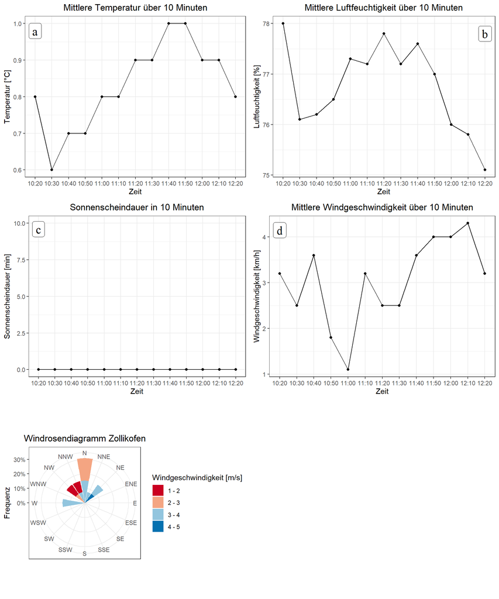

Fig. 1: Climatic situation at the MeteoSwiss station in Zollikofen

# 5 Statistics

Calculating mean, minimum and maximum value of each variable

Statistik Messstation Zollikofen

| Statistik | Temperatur | Rel. Luftfeuchtigkeit | Sonnenscheindauer | Windgeschwindikgeit |
| --- | --- | --- | --- | --- |
| Minimum | 0.6000000 | 75.10000 | 0 | 1.100000 |
| Maximum | 1.0000000 | 78.00000 | 0 | 4.300000 |
| Mittelwert | 0.8307692 | 76.75385 | 0 | 3.038461 |